MARKET ANALYSIS

**Date of Analysis:** 2020-07-30  
**Subject Property:** 2013 Scenic View Dr, Bakersfield, CA, 93307

Neighborhood Data

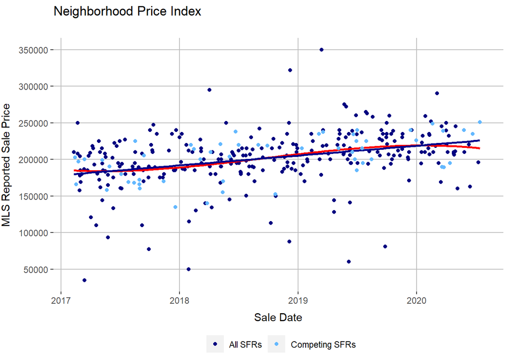

The above chart plots sale prices for all SFRs and competing SFRs, those with GLA of 1450 sf to 2150 sf, within the subject’s defined physical neighborhood boundaries over the past 3 years. The trend line demonstrates market conditions over said timeframe.

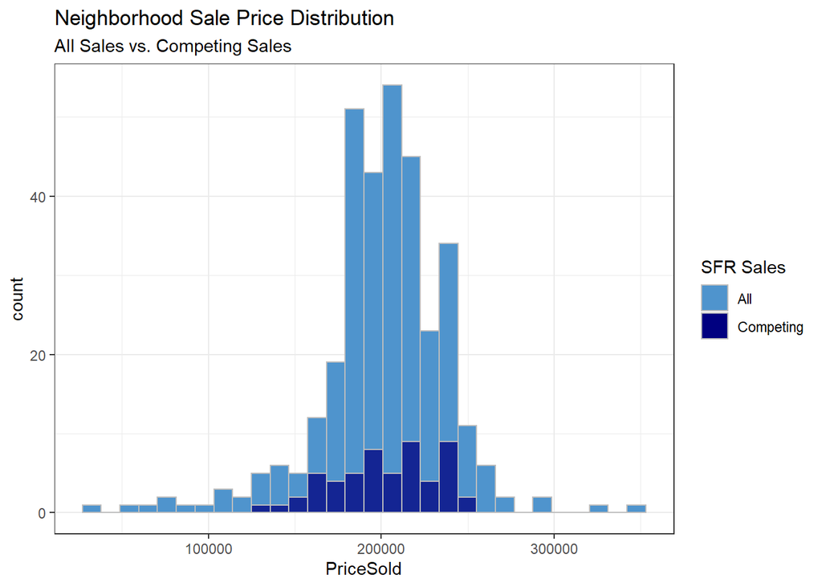

This histogram shows the distribution of sales volume by price for all SFRs in the neighborhood compared with those sales that directly compete with the subject property. Sale prices and volume are as reported in MLS based on a search within the neighborhood boundaries over the prior 3 years.

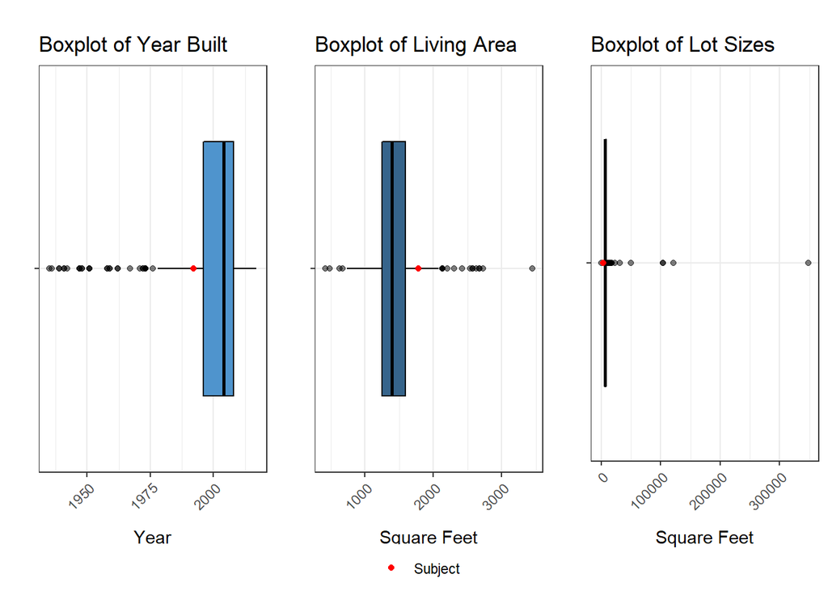

The above boxplots show the distribution of 3 primary characteristics in the subject’s neighborhood. The subject is identified in relation to the other homes in the neighborhood. The box area of each plot reflects 25-75% of the homes in the data, while the whiskers reflect the lower 25% and the upper 25%.

Competitive Market Segment Data

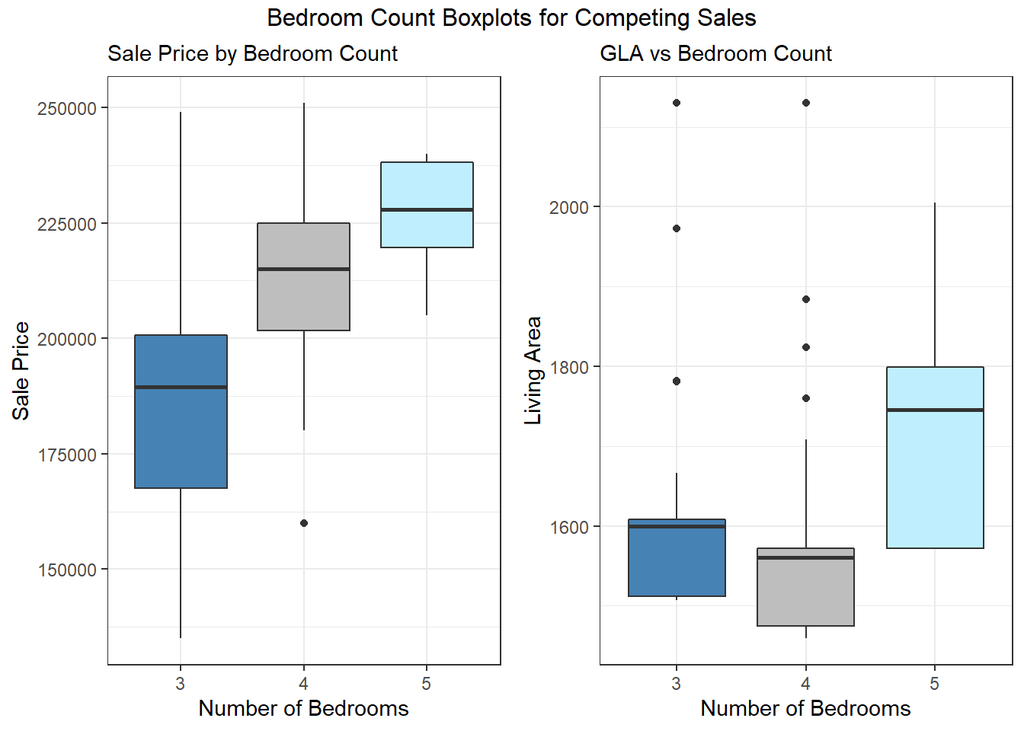

The above boxplots show the range of sale prices of competing homes based on bedroom count and the distribution of bedroom counts in relation to living area.

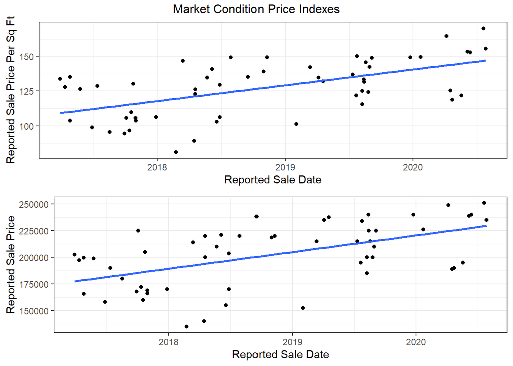

The top chart shows the change in price per square foot of competing sales over time. The slope of the linear regression indicates a change of $0.03 per day. The bottom chart shows the change in recorded sale prices over time. The slope of the linear regression indicates a change of $42.74 per day which I’ve rounded to $43.

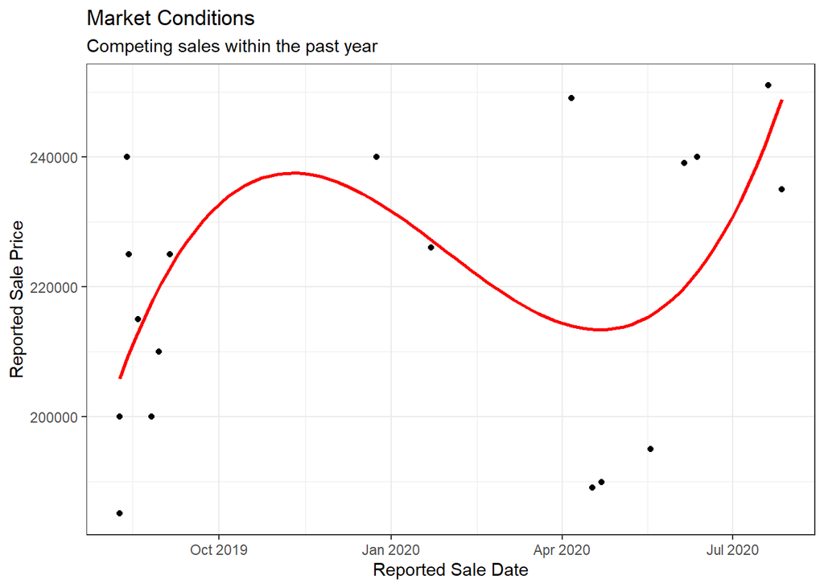

This chart drills down to the past 12 months showing the change in recorded sale prices of competing properties. The polynomial regression trend line demonstrates changes in market conditions.

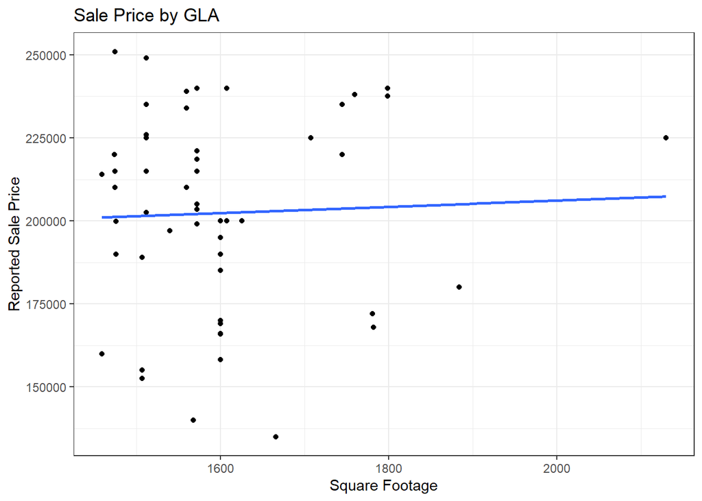

## Competing Market Segment Sales

| Address | Zip | DateSold | PriceSold | DOM | YrBlt | GLA | Bdrms | Baths | LotSF |
| --- | --- | --- | --- | --- | --- | --- | --- | --- | --- |
| 1125 Statkowski Ct | 93307 | 2020-07-27 | 235000 | 3 | 2005 | 1512 | 3 | 2.0 | 6551 |
| 1007 Berkshire Rd | 93307 | 2020-07-20 | 251000 | 36 | 2004 | 1475 | 4 | 2.0 | 6945 |
| 1309 Quartz Hill Rd | 93307 | 2020-06-12 | 240000 | 82 | 2003 | 1572 | 5 | 2.0 | 6534 |
| 1108 Quartz Hill Rd | 93307 | 2020-06-05 | 239000 | 3 | 2002 | 1560 | 4 | 2.0 | 6325 |
| 2017 Scenic View Dr | 93307 | 2020-05-18 | 195000 | 6 | 1992 | 1600 | 3 | 2.5 | 4692 |
| 1801 Scenic View Dr | 93307 | 2020-04-22 | 189900 | 5 | 1992 | 1600 | 3 | 2.5 | 4011 |
| 6604 Timber Cove Ct | 93307 | 2020-04-17 | 189000 | 48 | 1985 | 1507 | 3 | 2.5 | 3688 |
| 1118 Taos Way | 93307 | 2020-04-06 | 249000 | 35 | 2005 | 1512 | 3 | 2.0 | 6098 |
| 1108 Valdes Ct | 93307 | 2020-01-22 | 226000 | 62 | 2005 | 1512 | 3 | 2.0 | 6534 |
| 7919 Snowbird St | 93307 | 2019-12-24 | 240000 | 3 | 1996 | 1608 | 3 | 2.0 | 9148 |
| 1105 Statkowski Ct | 93307 | 2019-09-05 | 225000 | 13 | 2005 | 1512 | 3 | 2.0 | 6098 |
| 615 Berkshire Rd | 93307 | 2019-08-30 | 210000 | 159 | 2003 | 1475 | 4 | 2.0 | 7405 |
| 1412 Badger Pass Ave | 93307 | 2019-08-26 | 200000 | 52 | 1996 | 1608 | 3 | 2.0 | 8712 |
| 507 Minnatree Ln | 93307 | 2019-08-19 | 215000 | 8 | 2003 | 1475 | 4 | 2.0 | 6098 |
| 1101 Quartz Hill Rd | 93307 | 2019-08-14 | 225000 | 6 | 2002 | 1708 | 4 | 2.0 | 7405 |
| 403 Scarletfire Drive Dr | 93307 | 2019-08-13 | 240000 | 5 | 2005 | 1799 | 5 | 3.0 | 6534 |
| 6505 Sky View Dr | 93307 | 2019-08-09 | 200000 | 8 | 1992 | 1600 | 3 | 2.5 | 3714 |
| 6501 Sky View Dr | 93307 | 2019-08-09 | 185000 | 25 | 1992 | 1600 | 3 | 3.0 | 4801 |

In the past year there were 18 competing sales in the subject’s neighborhood with GLA of 1450 sf to 2150 sf and built between 1985 and 2005. All of these competing sales are included in the table above. Most of the sales have GLA of 1512 - 1600 sf. Year built ranges from 1985 to 2005 with most built 1993-2005. Lot sizes are 3688-9148 sf with the majority of homes on lots of 5125-6846 sf. Prices ranged from $185000 to $251000. Predominant sale prices are $200000 to $239750 with a median sale price of $225000.

*Map of the above sales*

[interactive chart not shown]